# Gene Ontology Analysis Snippet

## Plot Probability Distributions

Plot the `Weighted Overlap Prob` distribution and (unweighted) `Overlap Prob` distribution

- distributions of probabilities that given genes/proteins from a provided list are all identified within a given `GO Term`
- `weighted` accounts for list size, term size, frequency of a gene occurring in any term

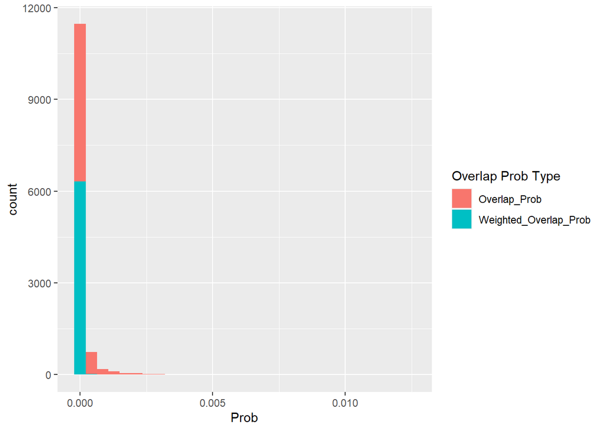

```r
  ## Inspect the probability distributions
GO_INFO_by_TERM_df %>%
  dplyr::select(GO_Term, Overlap_Prob, Weighted_Overlap_Prob) %>%
  pivot_longer(cols = c(contains("Overlap")),
               names_to = "Overlap Prob Type",
               values_to = "Prob") %>%
  ggplot(aes(x = Prob, fill = `Overlap Prob Type`)) +
  geom_histogram(aes(x = Prob))
```

# Hypothesis Test

Are the `Overlap Probabilities` significantly different than we would expect by chance?

- Perform a statistical test on each term’s `Overlap Probability`:
  - binomial exact test compares:
    1. the probability of the number of genes identified from the provided list involved in a particular `GO Term` (`Overlap Prob`)
    2. the theoretical (`Overlap Prob`) probability of the number of genes involved in a particular `GO Term`
       - theoretical probability is determined by:
         - simulating 1000 draws from a binomial distribution for a `GO Term` of the same size with the probability determined from the provided list (above)
         - averaging those 1000 numbers of simulated “successes”
         - dividing by the maximum number of genes in all `GO Term`s
  - test returns a p-value of a two-sided binomial exact test
- It is [known](https://geneontology.org/docs/faq/) that statistical results from this analysis may not be meaningful to the user because this approach will return large, vague `GO Terms` OR incredibly noisy and specific `GO Terms`, with a heavy dependence on the list size

## Binomial Exact Test 1

Perform an exact test across the derived probabilities for each `GO Term` to determine if that term is over- or under- represented within the provided list:

- `Weighted Overlap Probs` vs `Expected`
- `Unweighted Overlap Probs` vs `Expected`

```r
  ## Create variables for hypothetical probabilities, drawing from binomial distribution and performing an exact test
GO_INFO_by_TERM_df = GO_INFO_by_TERM_df %>%
  dplyr::mutate(E_Weighted_Overlap = NA_real_,
                E_Weighted_Overlap_Prob = NA_real_,
                Weighted_Overlap_Prob_p = NA_real_,
                E_Overlap = NA_real_,
                E_Overlap_Prob = NA_real_,
                Overlap_Prob_p = NA_real_)

  ## Fill variables
for( i in 1:nrow(GO_INFO_by_TERM_df) ) {

  ## what's the expected weighted overlap? probability? -> 1000 draws
    ## take the average of the 1000 draws for the overlap
      ## re-scale by factor of 10
  GO_INFO_by_TERM_df$E_Weighted_Overlap[i] = round(mean(
    rbinom(1000,
           size = GO_INFO_by_TERM_df$Num_Genes_in_Term[i],
           prob = GO_INFO_by_TERM_df$Weighted_Overlap_Prob[i]
           )
    ))

  ## same but un-weighted
  GO_INFO_by_TERM_df$E_Overlap[i] = round(mean(
    rbinom(n = 1000,
           size = GO_INFO_by_TERM_df$Num_Genes_in_Term[i],
           prob = GO_INFO_by_TERM_df$Overlap_Prob[i]
           )
    ))
}

    ## divide it by the total number of genes
GO_INFO_by_TERM_df$E_Weighted_Overlap_Prob =

  GO_INFO_by_TERM_df$E_Weighted_Overlap / max(GO_INFO_by_TERM_df$Num_Genes_in_Term)


GO_INFO_by_TERM_df$E_Overlap_Prob =

  GO_INFO_by_TERM_df$E_Overlap / max(GO_INFO_by_TERM_df$Num_Genes_in_Term)

for( i in 1:nrow(GO_INFO_by_TERM_df)) {
    ## perform an exact binomial test and extract p-values
  GO_INFO_by_TERM_df$Weighted_Overlap_Prob_p[i] =

    binom.test(GO_INFO_by_TERM_df$Num_Genes_in_Term_from_List[i],
               GO_INFO_by_TERM_df$Num_Genes_in_Term[i],
               (GO_INFO_by_TERM_df$E_Weighted_Overlap_Prob[i]),
               alternative = "two.sided")$p.value


  GO_INFO_by_TERM_df$Overlap_Prob_p[i] =

    binom.test(GO_INFO_by_TERM_df$Num_Genes_in_Term_from_List[i],
                GO_INFO_by_TERM_df$Num_Genes_in_Term[i],
                (GO_INFO_by_TERM_df$E_Overlap_Prob[i]),
                alternative = "two.sided")$p.value
}

  ## any significant? remove low count (1 hit) data and add adjusted p-values
GO_INFO_by_TERM_df %>%
  dplyr::arrange(Weighted_Overlap_Prob) %>%
  dplyr::mutate(Weighted_Overlap_Prob_ADJP = (Weighted_Overlap_Prob_p / nrow(GO_INFO_by_TERM_df)) * 0.05,
                 Overlap_Prob_ADJP = (Overlap_Prob_p / nrow(GO_INFO_by_TERM_df)) * 0.05) %>%
  dplyr::filter(Num_Genes_in_Term_from_List > 1) %>%
  dplyr::slice(c(1:15)) %>%
  dplyr::select(c(GO_Term, Num_Genes_in_Term_from_List, Num_Genes_in_Term, contains("Overlap")))
```

```
##                                                                                GO_Term
## 1                                                   actin filament bundle distribution
## 2                                        heparan sulfate 6-O-sulfotransferase activity
## 3           regulation of CDP-diacylglycerol-serine O-phosphatidyltransferase activity
## 4  positive regulation of CDP-diacylglycerol-serine O-phosphatidyltransferase activity
## 5                        positive regulation of serine C-palmitoyltransferase activity
## 6                          intrinsic component of neuronal dense core vesicle membrane
## 7                                   intrinsic component of dense core granule membrane
## 8                           integral component of neuronal dense core vesicle membrane
## 9                                               alpha-1,2-mannosyltransferase activity
## 10                                                           GTPase inhibitor activity
## 11                                             oncostatin-M-mediated signaling pathway
## 12                                                     mu-type opioid receptor binding
## 13                                                                   kininogen binding
## 14                                                                             C-fiber
```

[output cut: 65 more lines]

Results are plausible, given what we suspect about this dataset

Sorting by p-value returns a flood of 0 p-values (unhelpful)

## Plot Expected Probs vs Actual Probs

Plot the `Expected Overlap Probabilities` (x axis) and the `Overlap Probabilities` (y axis)

- `weighted overlap`
- `unweighted overlap`
- include a generalized additive model fit for each

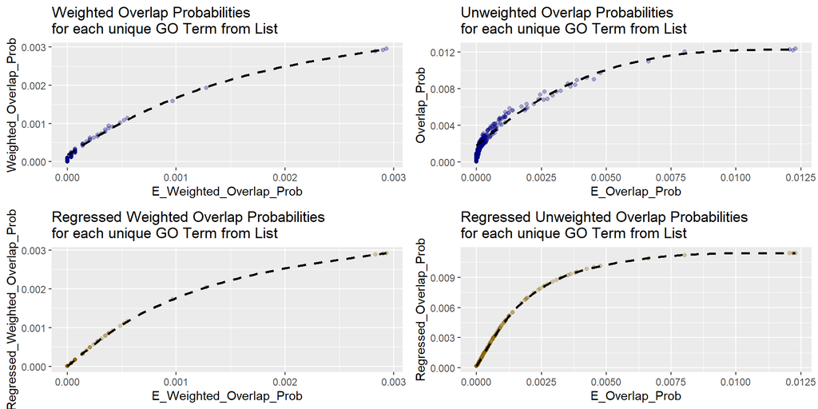

## Assess GAM Model fits

How does the weighted overlap compare?

```r
GO_INFO_by_TERM_df %>%
  dplyr::mutate(
                Weighted_Overlap_RMSE = sqrt(mean(weighted_gam_preds - Weighted_Overlap_Prob)^2),

                Overlap_RMSE = sqrt(mean(gam_preds - Overlap_Prob)^2),

                Weighted_gam_Preds_RMSE = sqrt(mean(gam_fit_on_weighted_gam_preds - Weighted_Overlap_Prob)^2),

                Unweighted_gam_Preds_RMSE = sqrt(mean(gam_fit_on_unweighted_gam_preds - Overlap_Prob)^2),

                ) %>%
  dplyr::select(contains("RMSE")) %>%
  dplyr::distinct() %>%
  pivot_longer(cols = c(colnames(.)))
```

```
## # A tibble: 4 × 2
##   name                            value
##   <chr>                           <dbl>
## 1 Weighted_Overlap_RMSE     0.000179
## 2 Overlap_RMSE              0.00162
## 3 Weighted_gam_Preds_RMSE   0.000000430
## 4 Unweighted_gam_Preds_RMSE 0.00000519
```

*We’ll use the* `regressed weighted GAM probabilities` in the `binomial exact test`

## Binomial Exact Test 2

Re-compute the binomial exact test using the `regressed weighted GAM fit values` as the the `Weighted Overlap Probabilities`

i.e. Regress the `Weighted Overlap Prob`s and use those regressed values as the theoretical probs in a `binomial exact test`

```r
GO_INFO_by_TERM_df = GO_INFO_by_TERM_df %>%
  dplyr::mutate(
    E_Weighted_Overlap_2 = NA_real_,
    E_Weighted_Overlap_Prob_2 = NA_real_,
    Weighted_Overlap_Prob_p_2 = NA_real_,
    Weighted_Overlap_Prob_ADJP_2 = NA_real_,
    E_Overlap_2 = NA_real_,
    E_Overlap_Prob_2 = NA_real_,
    Overlap_Prob_p_2 = NA_real_,
    Overlap_Prob_ADJP_2 = NA_real_
  )

for( i in 1:nrow(GO_INFO_by_TERM_df) ) {

  ## what's the expected weighted overlap? probability? -> 1000 draws; USE THE GAM PROB PREDICTS
    ## take the average of the 1000 draws for the overlap
  GO_INFO_by_TERM_df$E_Weighted_Overlap_2[i] = round(mean(
    rbinom(1000,
           size = GO_INFO_by_TERM_df$Num_Genes_in_Term[i],
           prob = GO_INFO_by_TERM_df$gam_fit_on_weighted_gam_preds[i]
           )
    )
  )

  GO_INFO_by_TERM_df$E_Overlap_2[i] = round(mean(
    rbinom(1000,
           size = GO_INFO_by_TERM_df$Num_Genes_in_Term[i],
           prob = GO_INFO_by_TERM_df$gam_fit_on_unweighted_gam_preds[i]
           )
  )
  )
}

    ## divide predicted overlap counts by total number of genes
GO_INFO_by_TERM_df$E_Weighted_Overlap_Prob_2 =

  GO_INFO_by_TERM_df$E_Weighted_Overlap_2 / max(GO_INFO_by_TERM_df$Num_Genes_in_Term)


GO_INFO_by_TERM_df$E_Overlap_Prob_2 =

  GO_INFO_by_TERM_df$E_Overlap_2 / max(GO_INFO_by_TERM_df$Num_Genes_in_Term)

    ## perform an exact binomial test and extract p-values
for( i in 1:nrow(GO_INFO_by_TERM_df) ) {

  GO_INFO_by_TERM_df$Weighted_Overlap_Prob_p_2[i] =

    binom.test(GO_INFO_by_TERM_df$Num_Genes_in_Term_from_List[i],
               GO_INFO_by_TERM_df$Num_Genes_in_Term[i],
               (GO_INFO_by_TERM_df$E_Weighted_Overlap_Prob_2[i]),
               alternative = "two.sided")$p.value

  GO_INFO_by_TERM_df$Overlap_Prob_p_2[i] =

    binom.test(GO_INFO_by_TERM_df$Num_Genes_in_Term_from_List[i],
               GO_INFO_by_TERM_df$Num_Genes_in_Term[i],
               (GO_INFO_by_TERM_df$E_Overlap_Prob_2[i]),
               alternative = "two.sided")$p.value

}


GO_INFO_by_TERM_df$Weighted_Overlap_Prob_ADJP_2 =

  (GO_INFO_by_TERM_df$Weighted_Overlap_Prob_p_2 / nrow(GO_INFO_by_TERM_df) ) * 0.05


GO_INFO_by_TERM_df$Overlap_Prob_ADJP_2 =

  (GO_INFO_by_TERM_df$Overlap_Prob_p_2 / nrow(GO_INFO_by_TERM_df) ) * 0.05
```